# Week 1: Elections

Janet Hernandez

2022-09-11

*This is my first weekly election blog posting for an ongoing assignment for the class Election Analytics at Harvard College with Professor Ryan Enos. Enjoy! :)*

I will be using the visualization customization extension for this blog post and will use the resulting data to make a prediction about the upcoming 2022 midterm election.

1. create a map of Republican/Democrat voteshare margin by state in a year of your choice,
2. create a map of Republican/Democrat voteshare margin by state and congressional district in 2014,
3. label each state (e.g. AZ) in your map and
4. create a custom ggplot2 theme for your blog.

**For my analysis, I’m picking the year 2016 since it is the most recent midterm year from the 114th Congress.**

Also, I am using a custom theme that replicates 538 theme that I found on GitHub. The source is linked at: https://github.com/alex23lemm/theme_fivethirtyeight/blob/master/theme_fivethirtyeight.R

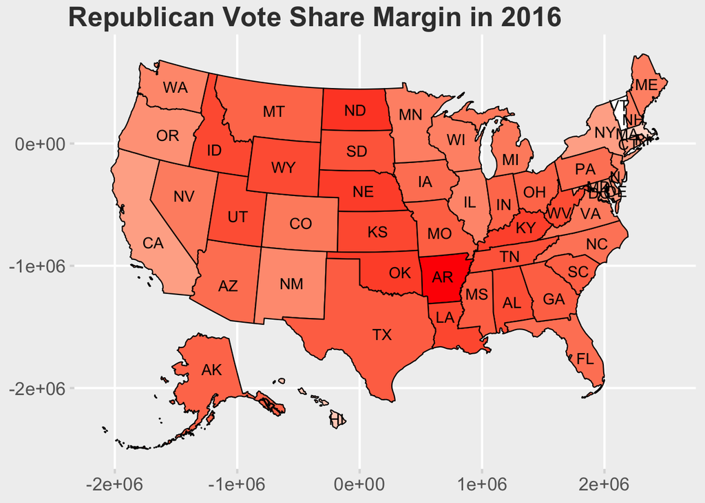

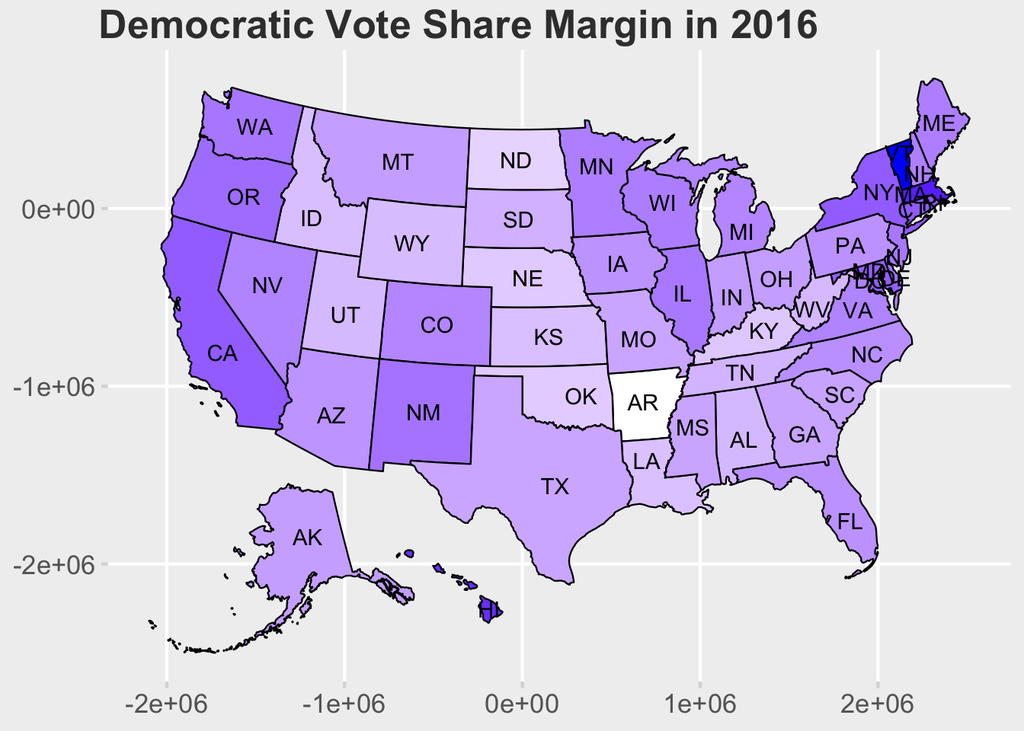

```r
# plot with simplify
districts_simp <- rmapshaper::ms_simplify(cd114, keep = 0.01)
```

[output not shown]

**Initial Prediction**

My initial prediction for the midterm election is that Republicans will once again regain control of the House of Representatives. Well known “swing states” will likely swing back from blue to red in this upcoming election. I believe that right now though, my opinion is quite uninformed as this is just speculation. I expect that as the weeks go on and I am able to match data to my assumptions that I may be swayed in opinion. Currently my week 1 estimate:

HOR: Republicans with a slight majority at 225 seats and Democrats with the remaining 210

Senate: A slight advantage for the Democrats with 52 Democratic seats while the remaining 48 go to Republicans.